# Central Limit Theorem: Exercises Solutions

Kateřina Večerková vecerkok@vscht.cz

2025-01-22

# Central Limit Theorem Exercises Solutions

## Exercise 1: Simulating a Population Distribution

Create a population distribution using a non-normal distribution (e.g., exponential or uniform). - Simulate a population of 10,000 values. - Plot the population distribution.

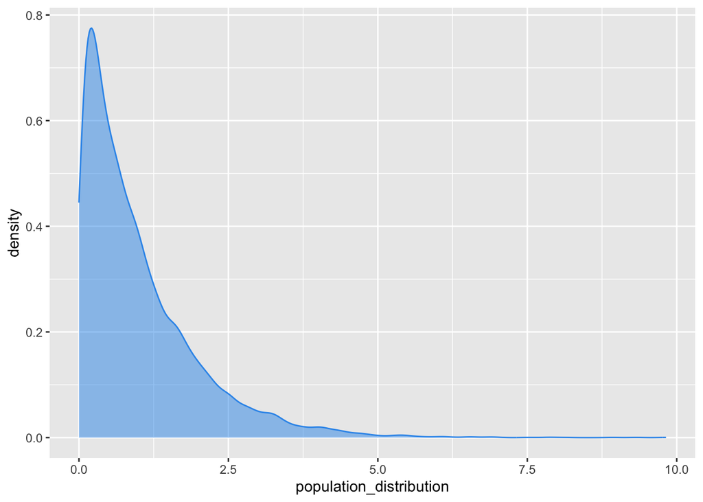

```r
library(ggplot2)
population_distribution <- rexp(10000, 1)
ggplot(as.data.frame(population_distribution), aes(x = population_distribution)) + geom_density(color = "#3498eb", fill = "#3498eb", alpha = 0.5)
```

## Exercise 2: Sampling from the Population

Take random samples from the population you created in Exercise 1. - Draw 30 random samples, each containing 50 observations. - Calculate and store the means of these samples.

```r
random_samples <- replicate(30, sample(population_distribution, size = 50, replace = TRUE))
random_samples_means <- apply(random_samples, 2, mean)
random_samples_means
```

```
##  [1] 0.7878495 1.1645826 1.0038269 1.0090963 1.1859334 1.1501656 1.0814176
##  [8] 0.8500211 0.8838772 0.9652396 0.8616205 1.2219332 0.9637803 0.9076940
## [15] 1.0819816 0.9835307 1.1093706 0.7864788 0.9565370 0.7615556 0.9910887
## [22] 1.2182954 1.0368451 0.9606121 1.0680329 1.2181073 0.9954393 0.7436555
## [29] 0.8449411 0.9691953
```

## Exercise 3: Distribution of Sample Means

Plot the distribution of the sample means you calculated in Exercise 2. - Use a histogram or density plot to visualize the distribution of sample means.

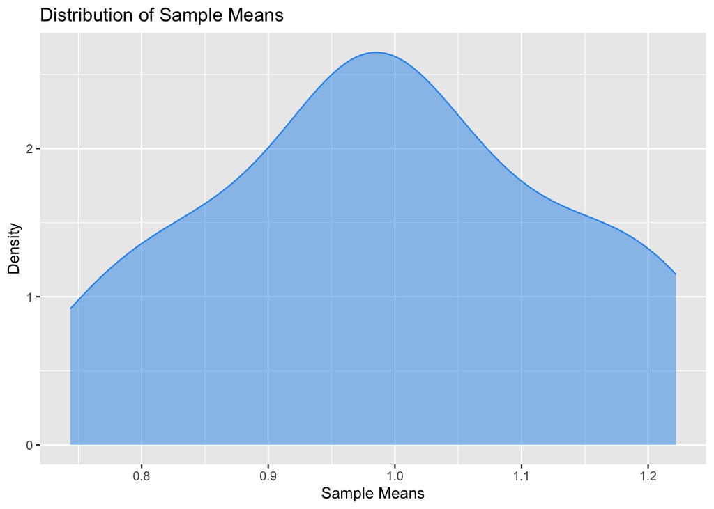

```r
ggplot(as.data.frame(random_samples_means), aes(x = random_samples_means)) + geom_density(color = "#3498eb", fill = "#3498eb", alpha = 0.5) + labs(title = "Distribution of Sample Means", x = "Sample Means", y = "Density")
```

## Exercise 4: Verifying the CLT

- Create a function to simulate sampling from the population and plotting the distribution of sample means.
- Test the function with different sample sizes (e.g., 10, 30, 100) and observe how the distribution of the sample means changes.

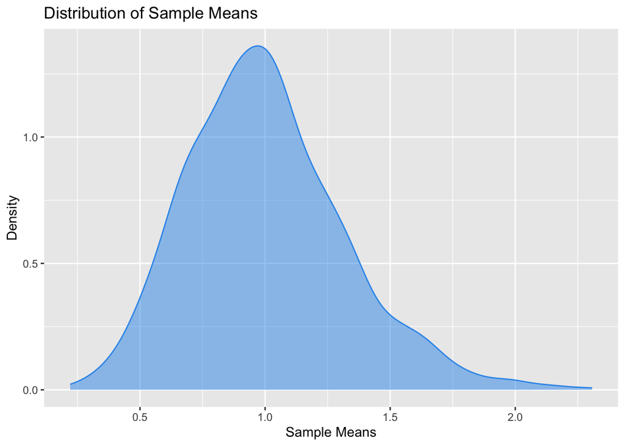

```r
plot_sample_means <- function(sample_size, num_samples, population_dist) {
  random_samples <- replicate(num_samples, sample(population_dist, size = sample_size, replace = TRUE))

  random_samples_means <- apply(random_samples, 2, mean)

  ggplot(as.data.frame(random_samples_means), aes(x = random_samples_means)) + geom_density(color = "#3498eb", fill = "#3498eb", alpha = 0.5) + labs(title = "Distribution of Sample Means", x = "Sample Means", y = "Density")
}

plot_sample_means(10, 1000, population_distribution)
```

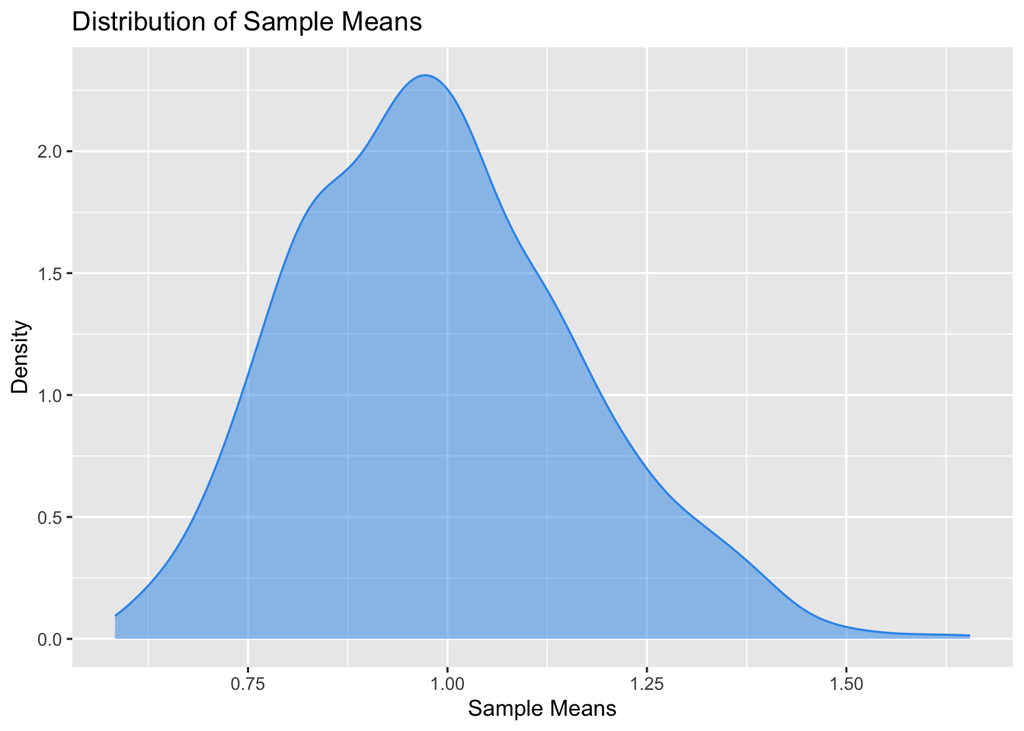

```r
plot_sample_means(30, 1000, population_distribution)
```

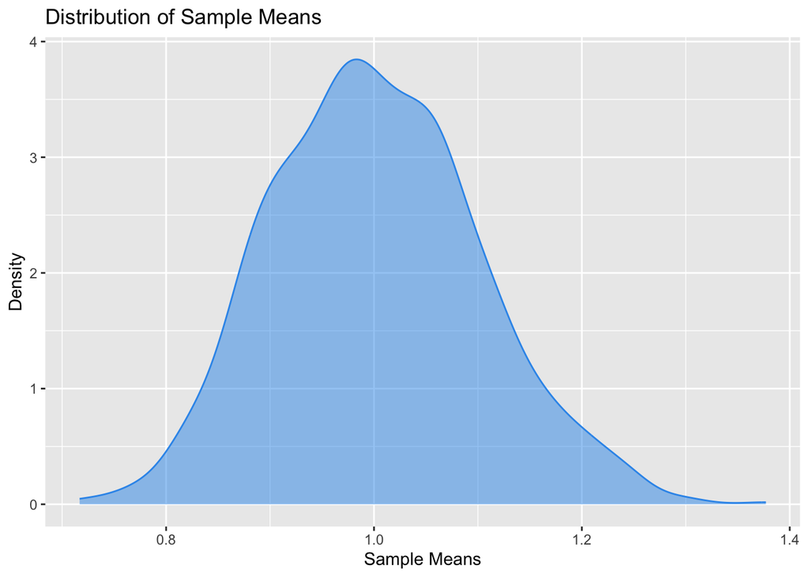

```r
plot_sample_means(100, 1000, population_distribution)
```